# TRABAJO EDA APRENDIZAJE AUTOMÁTICO

**Guzmán Muñoz Revuelta**

**Fernando Caruana del Pino**

# **OBJETIVOS DEL TRABAJO**

El objetivo de este trabajo es abordar el desafío de la detección de fraudes bancarios utilizando un conjunto de datos de detección de fraudes bancarios. La variable principal en este estudio es "bf" ("bank fraud") que representa la presencia o ausencia de fraude en las transacciones bancarias. La detección de fraudes bancarios es crucial para las instituciones financieras y los clientes con el fin de prevenir pérdidas económicas y mantener la confianza en el sistema bancario.

El trabajo se enfoca en los siguientes puntos clave:

1. Conjunto de Datos: Se utiliza un conjunto de datos que contiene información detallada sobre transacciones bancarias, incluyendo características relevantes como el monto de la transacción, la hora, el tipo de tarjeta utilizada, entre otros.
2. Análisis Exploratorio de Datos (EDA): Se realiza un EDA para comprender la distribución de la variable "bf" y explorar las relaciones entre las diferentes características y la variable objetivo. Esto ayuda a identificar posibles patrones de fraude.
3. Preprocesamiento de Datos: Se lleva a cabo un preprocesamiento de datos que puede incluir la normalización de características, la eliminación de valores atípicos y la codificación de variables categóricas.
4. Selección de Modelo: Se evalúan varios modelos de aprendizaje automático, como Regresión Logística, Random Forest, Support Vector Machines, o Redes Neuronales, para determinar cuál es el más adecuado para la detección de fraudes bancarios.
5. Entrenamiento y Evaluación del Modelo: El modelo seleccionado se entrena utilizando una parte del conjunto de datos y se evalúa utilizando métricas de rendimiento, como la precisión, la sensibilidad y la especificidad.
6. Optimización del Modelo: Se pueden realizar ajustes en el modelo y los hiperparámetros para mejorar su rendimiento.
7. Implementación en Producción: Una vez que se obtiene un modelo de detección de fraudes eficaz, se puede implementar en la operación bancaria en tiempo real para identificar transacciones sospechosas.

Este trabajo tiene como objetivo proporcionar una solución efectiva para la detección de fraudes bancarios utilizando la variable "bf" como variable principal. La detección de fraudes es esencial en el entorno financiero para prevenir pérdidas y proteger a los clientes de posibles actividades fraudulentas.

**Importamos las librerías necesarias**

```python
import pandas as pd
import numpy as np
import seaborn as sns
from matplotlib import pyplot as plt
import plotly.express as px
import warnings
from sklearn.impute import KNNImputer
import scipy.stats as ss

pd.set_option('display.max_columns', 500) #esto es para que me muestre todas las columnas
pd.set_option('display.max_rows', 5000) #esto es para que me muestre todas las filas
```

El dataframe bf 'bank frauds' es una base de datos donde vienen reflejadas varias variables (columnas) relacionadas con los fraudes bancarios, como pueden ser si existe algún tipo de fraude, el dominio del email (gratuito o de pago), etc. En este trabajo nuestra variable objetivo será 'fraud_bool', la cuál es una variable dummy donde 0 = no fraude y 1 = fraude.

```python
bf = pd.read_csv('../data/Base.csv', sep=',', decimal='.')
bf.head()
```

|  | fraud_bool | income | name_email_similarity | prev_address_months_count | current_address_months_count | customer_age | days_since_request | intended_balcon_amount | payment_type | zip_count_4w | velocity_6h | velocity_24h | velocity_4w | bank_branch_count_8w | date_of_birth_distinct_emails_4w | employment_status | credit_risk_score | email_is_free | housing_status | phone_home_valid | phone_mobile_valid | bank_months_count | has_other_cards | proposed_credit_limit | foreign_request | source | session_length_in_minutes | device_os | keep_alive_session | … |
| --- | --- | --- | --- | --- | --- | --- | --- | --- | --- | --- | --- | --- | --- | --- | --- | --- | --- | --- | --- | --- | --- | --- | --- | --- | --- | --- | --- | --- | --- | --- |
| 0 | 1 | 0.9 | 0.166828 | -1 | 88 | 50 | 0.020925 | -1.331345 | AA | 769 | 10650.765523 | 3134.319630 | 3863.647740 | 1 | 6 | CA | 185 | 0 | BA | 1 | 0 | 24 | 0 | 500.0 | 0 | INTERNET | 3.888115 | windows | 0 | … |
| 1 | 1 | 0.9 | 0.296286 | -1 | 144 | 50 | 0.005418 | -0.816224 | AB | 366 | 534.047319 | 2670.918292 | 3124.298166 | 718 | 3 | CA | 259 | 1 | BA | 0 | 0 | 15 | 0 | 1500.0 | 0 | INTERNET | 31.798819 | windows | 0 | … |
| 2 | 1 | 0.9 | 0.044985 | -1 | 132 | 40 | 3.108549 | -0.755728 | AC | 870 | 4048.534263 | 2893.621498 | 3159.590679 | 1 | 14 | CB | 177 | 1 | BA | 0 | 1 | -1 | 0 | 200.0 | 0 | INTERNET | 4.728705 | other | 0 | … |
| 3 | 1 | 0.9 | 0.159511 | -1 | 22 | 50 | 0.019079 | -1.205124 | AB | 810 | 3457.064063 | 4054.908412 | 3022.261812 | 1921 | 6 | CA | 110 | 1 | BA | 0 | 1 | 31 | 1 | 200.0 | 0 | INTERNET | 2.047904 | linux | 0 | … |
| 4 | 1 | 0.9 | 0.596414 | -1 | 218 | 50 | 0.004441 | -0.773276 | AB | 890 | 5020.341679 | 2728.237159 | 3087.670952 | 1990 | 2 | CA | 295 | 1 | BA | 1 | 0 | 31 | 0 | 1500.0 | 0 | INTERNET | 3.775225 | macintosh | 1 | … |

```python
bf.dtypes
```

```
fraud_bool                            int64
income                              float64
name_email_similarity               float64
prev_address_months_count             int64
current_address_months_count          int64
customer_age                          int64
days_since_request                  float64
intended_balcon_amount              float64
payment_type                         object
zip_count_4w                          int64
velocity_6h                         float64
velocity_24h                        float64
velocity_4w                         float64
bank_branch_count_8w                  int64
date_of_birth_distinct_emails_4w      int64
employment_status                    object
credit_risk_score                     int64
email_is_free                         int64
housing_status                       object
phone_home_valid                      int64
phone_mobile_valid                    int64
bank_months_count                     int64
has_other_cards                       int64
proposed_credit_limit               float64
foreign_request                       int64
source                               object
session_length_in_minutes           float64
device_os                            object
keep_alive_session                    int64
device_distinct_emails_8w             int64
device_fraud_count                    int64
month                                 int64
dtype: object
```

Como el enunciado nos indica, tenemos algunas variables que están en un tipo incorrecto, por lo que hemos creado un diccionario con las variables y su formato correcto, lo hemos visto en la tabla de Variables donde entre paréntesis ponía el tipo adecuado para cada variable. Hemos nombrado la nueva variable como new_bf, y como se puede ver, la variable principal 'bf' ha pasado de número int (entero) a categórica.

```python
# creamos un diccionario con las variables, cambiando el tipo de dato a las que nos interesan.
new_types = {'fraud_bool': 'category', 'income': 'float', 'name_email_similarity': 'float', 'prev_address_months_count': 'int64', 'current_address_months_count': 'int64', 'customer_age': 'int64', 'days_since_request': 'float64', 'intended_balcon_amount': 'float', 'payment_type': 'category', 'zip_count_4w': 'int64', 'velocity_6h': 'float', 'velocity_24h': 'float', 'velocity_4w': 'float', 'bank_branch_count_8w': 'int64', 'date_of_birth_distinct_emails_4w': 'int64', 'employment_status': 'category', 'credit_risk_score': 'int64', 'email_is_free': 'category', 'housing_status': 'category', 'phone_home_valid': 'category', 'phone_mobile_valid': 'category', 'bank_months_count': 'int64', 'has_other_cards': 'category', 'proposed_credit_limit': 'int64', 'foreign_request': 'category', 'source': 'category', 'session_length_in_minutes': 'float', 'device_os': 'category', 'keep_alive_session': 'category', 'device_distinct_emails_8w': 'int64', 'device_fraud_count': 'int64', 'month': 'int64'}

# cambiamos esas variables en nuestro dataset
new_bf = bf.astype(new_types)
```

Los nuevos tipos de variable:

```python
new_bf.dtypes
```

```
fraud_bool                          category
income                               float64
name_email_similarity                float64
prev_address_months_count              int64
current_address_months_count           int64
customer_age                           int64
days_since_request                   float64
intended_balcon_amount               float64
payment_type                        category
zip_count_4w                           int64
velocity_6h                          float64
velocity_24h                         float64
velocity_4w                          float64
bank_branch_count_8w                   int64
date_of_birth_distinct_emails_4w       int64
employment_status                   category
credit_risk_score                      int64
email_is_free                       category
housing_status                      category
phone_home_valid                    category
phone_mobile_valid                  category
bank_months_count                      int64
has_other_cards                     category
proposed_credit_limit                  int64
foreign_request                     category
source                              category
session_length_in_minutes            float64
device_os                           category
keep_alive_session                  category
device_distinct_emails_8w              int64
device_fraud_count                     int64
month                                  int64
dtype: object
```

```python
new_bf['proposed_credit_limit']
```

```
0          500
1         1500
2          200
3          200
4         1500
          ...
999995     200
999996     200
999997     200
999998     500
999999     200
Name: proposed_credit_limit, Length: 1000000, dtype: int64
```

```python
new_bf.dtypes.to_dict()
```

```
{'fraud_bool': CategoricalDtype(categories=[0, 1], ordered=False),
 'income': dtype('float64'),
 'name_email_similarity': dtype('float64'),
 'prev_address_months_count': dtype('int64'),
 'current_address_months_count': dtype('int64'),
 'customer_age': dtype('int64'),
 'days_since_request': dtype('float64'),
 'intended_balcon_amount': dtype('float64'),
 'payment_type': CategoricalDtype(categories=['AA', 'AB', 'AC', 'AD', 'AE'], ordered=False),
 'zip_count_4w': dtype('int64'),
 'velocity_6h': dtype('float64'),
 'velocity_24h': dtype('float64'),
 'velocity_4w': dtype('float64'),
 'bank_branch_count_8w': dtype('int64'),
 'date_of_birth_distinct_emails_4w': dtype('int64'),
 'employment_status': CategoricalDtype(categories=['CA', 'CB', 'CC', 'CD', 'CE', 'CF', 'CG'], ordered=False),
 'credit_risk_score': dtype('int64'),
 'email_is_free': CategoricalDtype(categories=[0, 1], ordered=False),
 'housing_status': CategoricalDtype(categories=['BA', 'BB', 'BC', 'BD', 'BE', 'BF', 'BG'], ordered=False),
 'phone_home_valid': CategoricalDtype(categories=[0, 1], ordered=False),
 'phone_mobile_valid': CategoricalDtype(categories=[0, 1], ordered=False),
 'bank_months_count': dtype('int64'),
 'has_other_cards': CategoricalDtype(categories=[0, 1], ordered=False),
 'proposed_credit_limit': dtype('int64'),
 'foreign_request': CategoricalDtype(categories=[0, 1], ordered=False),
 'source': CategoricalDtype(categories=['INTERNET', 'TELEAPP'], ordered=False),
 'session_length_in_minutes': dtype('float64'),
 'device_os': CategoricalDtype(categories=['linux', 'macintosh', 'other', 'windows', 'x11'], ordered=False),
 'keep_alive_session': CategoricalDtype(categories=[0, 1], ordered=False),
 'device_distinct_emails_8w': dtype('int64'),
 'device_fraud_count': dtype('int64'),
 'month': dtype('int64')}
```

```python
%pip install sweetviz
```

```python
from IPython.display import Image
```

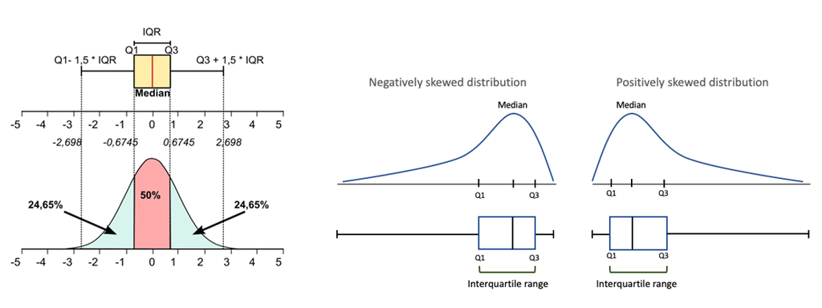

```python
def plot_feature(df, col_name, isContinuous, target):
    """
    Visualize a variable with and without faceting on the loan status.
    - df dataframe
    - col_name is the variable name in the dataframe
    - full_name is the full variable name
    - continuous is True if the variable is continuous, False otherwise
    """
    f, (ax1, ax2) = plt.subplots(nrows=1, ncols=2, figsize=(12,3), dpi=90)

    count_null = df[col_name].isnull().sum()
    if isContinuous:

        sns.histplot(df.loc[df[col_name].notnull(), col_name], kde=False, ax=ax1)
    else:
        sns.countplot(df,x=col_name, color='#5975A4', saturation=1, ax=ax1)
    ax1.set_xlabel(col_name)
    ax1.set_ylabel('Count')
    ax1.set_title(col_name+ ' Numero de nulos: '+str(count_null))
    plt.xticks(rotation = 90)


    if isContinuous:
        sns.boxplot(x=col_name, y=target, data=df, ax=ax2)
        ax2.set_ylabel('')
        ax2.set_title(col_name + ' by '+target)
    else:
        data = df.groupby(col_name)[target].value_counts(normalize=True).to_frame('proportion').reset_index()
        data.columns = [i, target, 'proportion']
        #sns.barplot(x = col_name, y = 'proportion', hue= target, data = data, saturation=1, ax=ax2)
        sns.barplot(x = col_name, y = 'proportion', hue= target, data = data, saturation=1, ax=ax2)
        ax2.set_ylabel(target+' fraction')
        ax2.set_title(target)
        plt.xticks(rotation = 90)
    ax2.set_xlabel(col_name)

    plt.tight_layout()


def get_corr_matrix(dataset = None, metodo='pearson', size_figure=[10,8]):
    # Para obtener la correlación de Spearman, sólo cambiar el metodo por 'spearman'

    if dataset is None:
        print(u'\nHace falta pasar argumentos a la función')
        return 1
    sns.set(style="white")
    # Compute the correlation matrix
    corr = dataset.corr(method=metodo)
    # Set self-correlation to zero to avoid distraction
    for i in range(corr.shape[0]):
        corr.iloc[i, i] = 0
    # Set up the matplotlib figure
    f, ax = plt.subplots(figsize=size_figure)
    # Draw the heatmap with the mask and correct aspect ratio
    sns.heatmap(corr, center=0,
                square=True, linewidths=.5,  cmap ='viridis' ) #cbar_kws={"shrink": .5}
    plt.show()

    return 0

def get_deviation_of_mean_perc(bf, list_var_continuous, target, multiplier):
    """
    Devuelve el porcentaje de valores que exceden del intervalo de confianza
    :type series:
    :param multiplier:
    :return:
    """
    pd_final = pd.DataFrame()

    for i in list_var_continuous:

        series_mean = bf[i].mean()
        series_std = bf[i].std()
        std_amp = multiplier * series_std
        left = series_mean - std_amp
        right = series_mean + std_amp
        size_s = bf[i].size

        perc_goods = bf[i][(bf[i] >= left) & (bf[i] <= right)].size/size_s
        perc_excess = bf[i][(bf[i] < left) | (bf[i] > right)].size/size_s

        if perc_excess>0:
            pd_concat_percent = pd.DataFrame(bf[target][(bf[i] < left) | (bf[i] > right)]\
                                            .value_counts(normalize=True).reset_index()).T
            pd_concat_percent.columns = [pd_concat_percent.iloc[0,0],
                                         pd_concat_percent.iloc[0,1]]
            pd_concat_percent = pd_concat_percent.drop('index',axis=0)
            pd_concat_percent['variable'] = i
            pd_concat_percent['sum_outlier_values'] = bf[i][(bf[i] < left) | (bf[i] > right)].size
            pd_concat_percent['porcentaje_sum_null_values'] = perc_excess
            pd_final = pd.concat([pd_final, pd_concat_percent], axis=0).reset_index(drop=True)

    if pd_final.empty:
        print('No existen variables con valores nulos')

    return pd_final


def get_percent_null_values_target(bf, list_var_continuous, target):

    pd_final = pd.DataFrame()
    for i in list_var_continuous:
        if bf[i].isnull().sum()>0:
            pd_concat_percent = pd.DataFrame(bf[target][bf[i].isnull()]\
                                            .value_counts(normalize=True).reset_index()).T
            pd_concat_percent.columns = [pd_concat_percent.iloc[0,0],
                                         pd_concat_percent.iloc[0,1]]
            pd_concat_percent = pd_concat_percent.drop('index',axis=0)
            pd_concat_percent['variable'] = i
            pd_concat_percent['sum_null_values'] = bf[i].isnull().sum()
            pd_concat_percent['porcentaje_sum_null_values'] = bf[i].isnull().sum()/bf.shape[0]
            pd_final = pd.concat([pd_final, pd_concat_percent], axis=0).reset_index(drop=True)

    if pd_final.empty:
        print('No existen variables con valores nulos')

    return pd_final



def cramers_v(confusion_matrix):
    """
    calculate Cramers V statistic for categorial-categorial association.
    uses correction from Bergsma and Wicher,
    Journal of the Korean Statistical Society 42 (2013): 323-328

    confusion_matrix: tabla creada con pd.crosstab()

    """
    chi2 = ss.chi2_contingency(confusion_matrix)[0]
    n = confusion_matrix.sum()
    phi2 = chi2 / n
    r, k = confusion_matrix.shape
    phi2corr = max(0, phi2 - ((k-1)*(r-1))/(n-1))
    rcorr = r - ((r-1)**2)/(n-1)
    kcorr = k - ((k-1)**2)/(n-1)
    return np.sqrt(phi2corr / min((kcorr-1), (rcorr-1)))
```

A la vista del gráfico de abajo ('Porcentaje de fraudes'), podemos observar que el 98.9% son valores 0, es decir, de no fraude; y el 1,10 restante son valores 1, es decir fraude.

```python
new_bf['fraud_bool'].value_counts(normalize=True)
```

```
0    0.988971
1    0.011029
Name: fraud_bool, dtype: float64
```

**Lo reflejamos en un gráfico de barras:**

```python
import plotly.express as px

pd_plot_fraud_bool = new_bf['fraud_bool']\
    .value_counts(normalize=True)\
    .mul(100).rename('percent').reset_index()

pd_plot_fraud_bool_conteo = new_bf['fraud_bool'].value_counts().reset_index()
pd_plot_fraud_bool_pc = pd.merge(pd_plot_fraud_bool,
                                 pd_plot_fraud_bool_conteo, left_index=True, right_index=True, how='inner')

fig = px.bar(pd_plot_fraud_bool_pc, x=pd_plot_fraud_bool_pc.index, y=['percent'])
fig.update_layout(title='Porcentaje de fraudes',
                   xaxis_title='Fraude',
                   yaxis_title='Porcentaje')
fig.show()
```

[output not shown]

```python
from sklearn.model_selection import train_test_split
X_bf, X_bf_test, y_bf, y_bf_test = train_test_split(new_bf.drop('fraud_bool',axis=1),
                                                                     new_bf['fraud_bool'],
                                                                     stratify=new_bf['fraud_bool'],
                                                                     test_size=0.2)
bf_train = pd.concat([X_bf, y_bf],axis=1)
bf_test = pd.concat([X_bf_test, y_bf_test],axis=1)
```

La función 'train_test_split' toma como argumentos el conjunto de datos a dividir ('new_bf.drop('fraud_bool',axis=1)'), la variable objetivo ('new_bf['fraud_bool']'), la proporción del conjunto de datos que se utilizará para el conjunto de prueba ('test_size=0.2') y la estratificación ('stratify=new_bf['fraud_bool']') para asegurarse de que la proporción de la variable objetivo en el conjunto de prueba sea similar a la del conjunto de datos original.

El resultado de la función 'train_test_split' son cuatro conjuntos de datos: 'X_bf', 'X_bf_test', 'y_bf' y 'y_bf_test'. 'X_bf' y 'y_bf' son los conjuntos de datos de entrenamiento, mientras que 'X_bf_test' y 'y_bf_test' son los conjuntos de datos de prueba.

Finalmente, se concatenan 'X_bf' y 'y_bf' en 'bf_train' y 'X_bf_test' y 'y_bf_test' en 'bf_test'.

```python
bf_train.dtypes
```

```
income                               float64
name_email_similarity                float64
prev_address_months_count              int64
current_address_months_count           int64
customer_age                           int64
days_since_request                   float64
intended_balcon_amount               float64
payment_type                        category
zip_count_4w                           int64
velocity_6h                          float64
velocity_24h                         float64
velocity_4w                          float64
bank_branch_count_8w                   int64
date_of_birth_distinct_emails_4w       int64
employment_status                   category
credit_risk_score                      int64
email_is_free                       category
housing_status                      category
phone_home_valid                    category
phone_mobile_valid                  category
bank_months_count                      int64
has_other_cards                     category
proposed_credit_limit                  int64
foreign_request                     category
source                              category
session_length_in_minutes            float64
device_os                           category
keep_alive_session                  category
device_distinct_emails_8w              int64
device_fraud_count                     int64
month                                  int64
fraud_bool                          category
dtype: object
```

```python
print('== Train\n', bf_train['fraud_bool'].value_counts(normalize=True))
print('== Test\n', bf_test['fraud_bool'].value_counts(normalize=True))
```

```
== Train
 0    0.988971
1    0.011029
Name: fraud_bool, dtype: float64
== Test
 0    0.98897
1    0.01103
Name: fraud_bool, dtype: float64
```

```python
pd_series_null_columns = bf_train.isnull().sum().sort_values(ascending=False)
pd_series_null_rows = bf_train.isnull().sum(axis=1).sort_values(ascending=False)
print(pd_series_null_columns.shape, pd_series_null_rows.shape)

pd_null_columnas = pd.DataFrame(pd_series_null_columns, columns=['nulos_columnas'])
pd_null_filas = pd.DataFrame(pd_series_null_rows, columns=['nulos_filas'])
pd_null_filas['target'] = bf['fraud_bool'].copy()
pd_null_columnas['porcentaje_columnas'] = pd_null_columnas['nulos_columnas']/bf_train.shape[0]
pd_null_filas['porcentaje_filas']= pd_null_filas['nulos_filas']/bf_train.shape[1]
```

```
(32,) (800000,)
```

# VISUALIZACIÓN DE LOS GRÁFICOS

```python
list_var_numeric = list(new_bf.select_dtypes(include=['float64', 'int64']).columns)
```

```python
list_var_cat = list(new_bf.select_dtypes(include=['category']).columns)
list_var_cat.remove('fraud_bool')
```

```python
list_var_numeric
```

```
['income',
 'name_email_similarity',
 'prev_address_months_count',
 'current_address_months_count',
 'customer_age',
 'days_since_request',
 'intended_balcon_amount',
 'zip_count_4w',
 'velocity_6h',
 'velocity_24h',
 'velocity_4w',
 'bank_branch_count_8w',
 'date_of_birth_distinct_emails_4w',
 'credit_risk_score',
 'bank_months_count',
 'proposed_credit_limit',
 'session_length_in_minutes',
 'device_distinct_emails_8w',
 'device_fraud_count',
 'month']
```

```python
list_var_cat
```

```
['payment_type',
 'employment_status',
 'email_is_free',
 'housing_status',
 'phone_home_valid',
 'phone_mobile_valid',
 'has_other_cards',
 'foreign_request',
 'source',
 'device_os',
 'keep_alive_session']
```

En nuestro dataframe 'bf_train' hay 20 variables numéricas (int y float) y 12 categóricas(category). Para que los gráficos se vean adecuadamente, hemos separado el dataset en función de eso, creando dos listas: list_var_numeric y list_var_cat. Al no funcionarnos bien el código inicial, Ana nos comentó que creáramos dos bucles, uno para cada lista, y ambos cogidos de 'bf_train' (los códigos de los gráficos se pueden ver más abajo). La principal diferencia entre ambos bucles (aparte de la lista), es que como las numéricas son continuas (isContinuous = True), en los gráficos de la derecha observaremos boxplots, mientras que en las categóricas, que no son continuas (isContinuous = False), veremos gráficos de barras.

Al principio no salía un error al ejecutar el código de las categóricas, ya que habíamos metido la propia variable target dentro de la lista, y cuando se comparaba con ella misma no se ejecutaba correctamente. Por lo que la hemos quitado y en el siguiente comando la hemos vuelto a añadir.

Este conjunto de 31 gráficos (las 31 columnas de nuestro dataframe sin contar la variable objetivo) compara nuestra variable target: 'fraud_bool' con el resto de variables. En los gráficos de la izquierda podemos observar el total de casos de cada dato de cada variable (la cuenta), generalmente representado en gráficos de columnas. En los gráficos de la derecha aparecen relacionadas cada variable con la variable target, en boxplots o gráficos de columnas.

# VARIABLES NUMÉRICAS

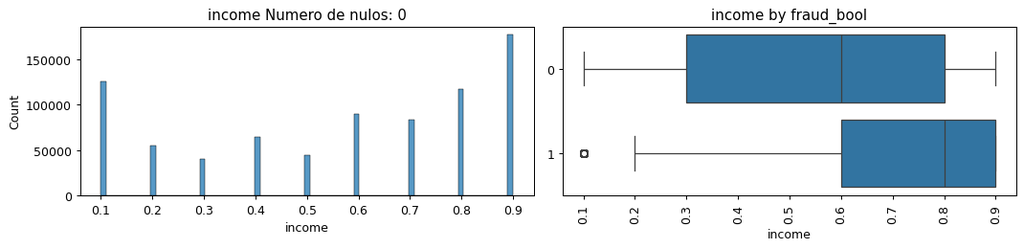

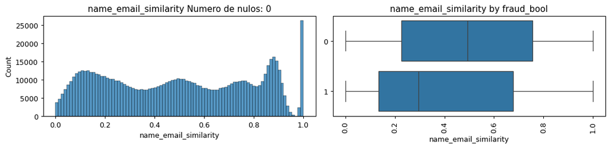

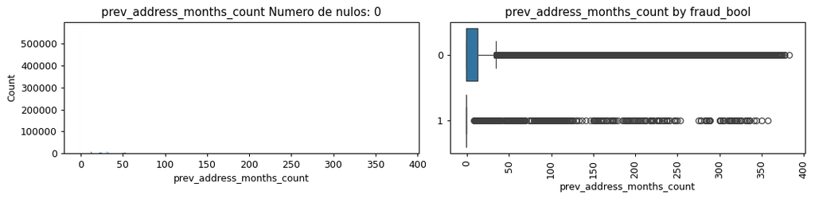

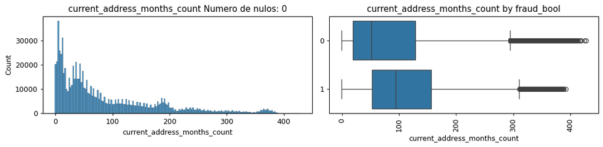

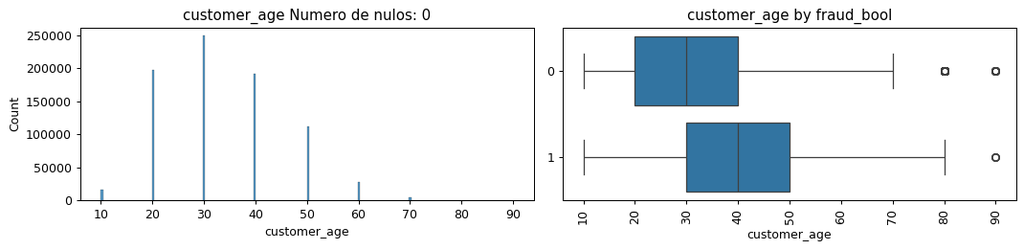

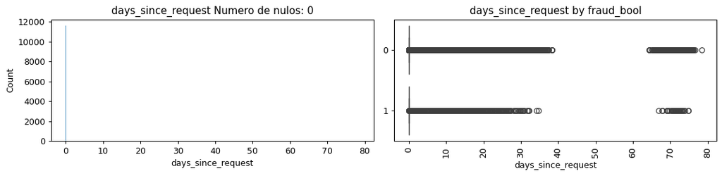

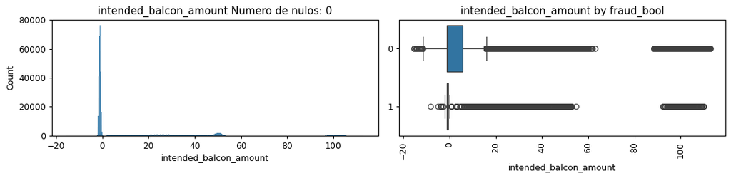

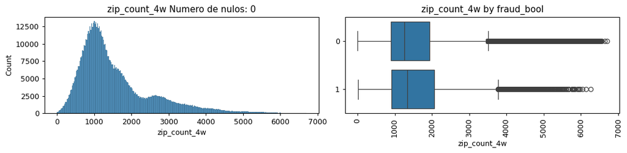

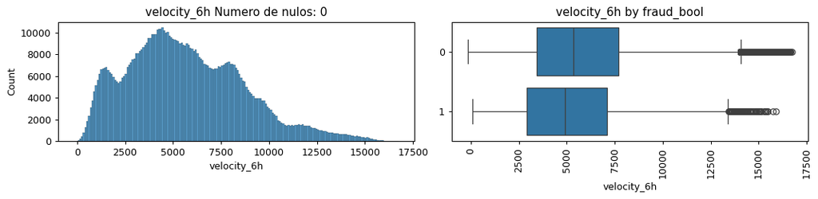

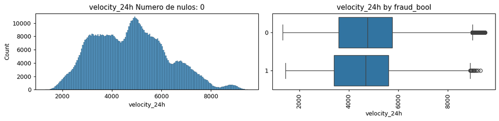

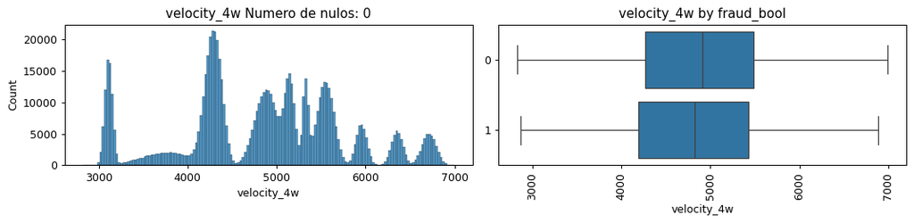

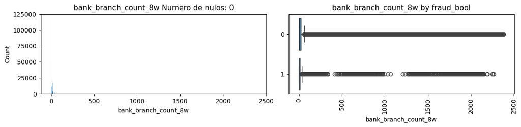

[8 more figures not shown]

```python
import warnings
warnings.filterwarnings('ignore')
#for i in list(bf_train.columns):
for i in list_var_numeric:
    plot_feature(bf_train, col_name=i, isContinuous=True, target='fraud_bool')



#hay que esperar un poco para que se vean las gráficas
```

Graficos variable sola: Los gráficos que se encuentran a la izquierda realizan una serie de gráficos de barras de cada una de las variables numéricas con en las cuales cuentan la cantidad de usuarios según sus datos diferenciado, por ejemplo: En la primera gráfica denominada income aparecen los ingresos de los usuarios donde la mayoría de ellos pertenecen a 0.9 con más de 150.000 usuarios.

Gráficos variables fraud_bool: Los gráficos que se encuentran a la derecha, realizan un boxplot con las mismas variables que aparecen a su izquierda diferenciados con la variable fraud_bool, donde 0 son los usuarios que no realizan fraude y 1 son los usuarios que realizan fraude, por ejemplo:En la primera gráfica income by_fraud_bool se puede observar que la caja de los usuarios que no realizan fraude tienen una caja más amplia que recorre ingresos entre 0.3 y 0.8 con una mediana de 0.6.Sin embargo, la caja de los usuarios que realizan fraude se encuentran en una caja menor entre 0.6 y 0.9 con una mayor mediana que se encuentra en 0.8.

# VARIABLES CATEGÓRICAS

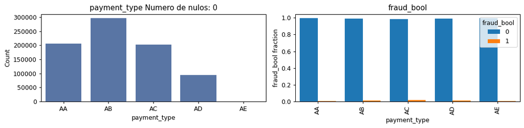

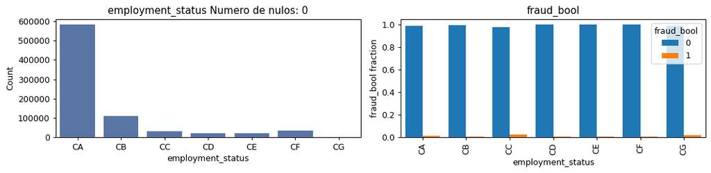

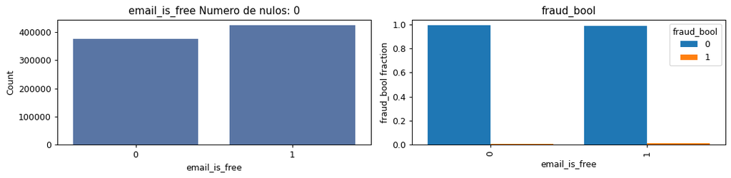

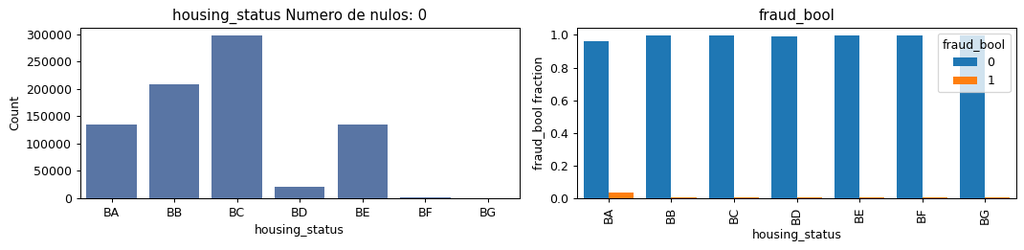

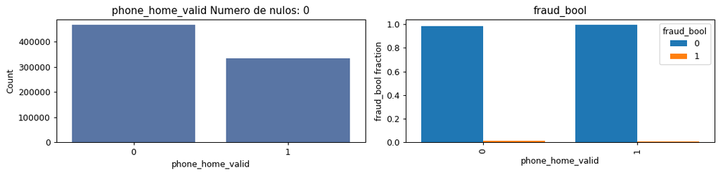

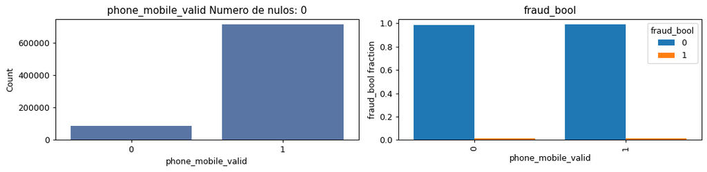

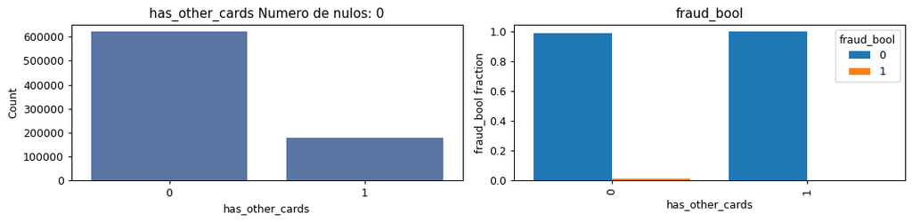

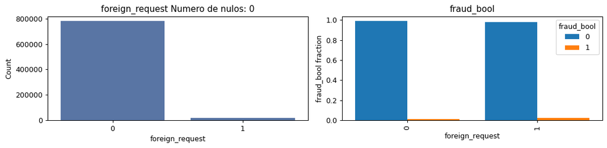

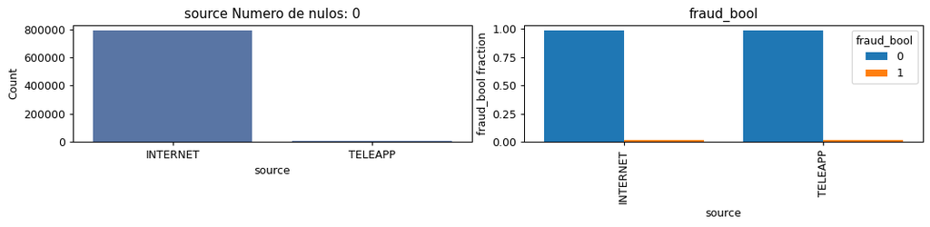

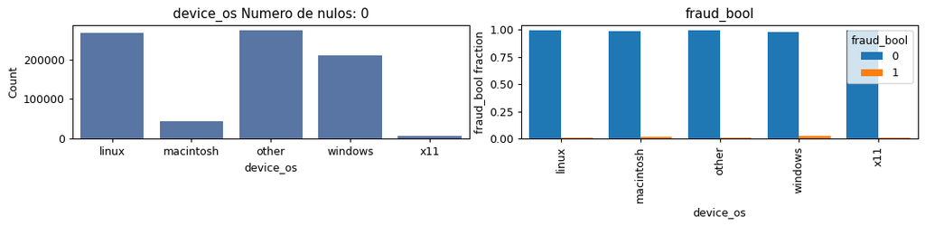

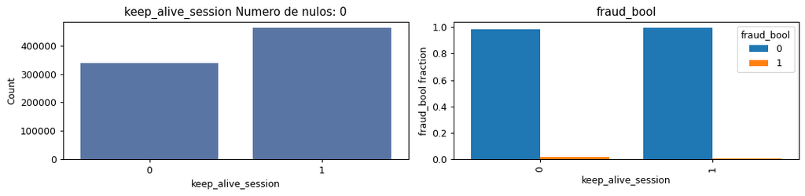

```python
import warnings
for i in list_var_cat:
    plot_feature(bf_train, col_name=i, isContinuous=False, target='fraud_bool')
```

En las variables categóricas observamos dos gráficos de barras por variable, el de la izquierda son los datos de cada variable y el de la derecha son datos comparados con nuestra variable target. A la vista de los datos podemos ver que los fraudes son mínimos.

Como comentario general de todos los gráficos se puede decir que las variables númericas explican mejor a nuestra variable target ('fraud_bool'), es decir, es mucho más cuantitativo comparar la edad del cliente con los fraudes que el aparato en el que se ha realizado la operación. No podemos elegir alguna variable categórica más 'importante' a la hora de compararlo, hay que seleccionar variables continuas como haremos más adelante.

```python
list_var_cat = list(new_bf.select_dtypes(include=['category']).columns)
```

Añadimos otra vez nuestra variable target 'fraud_bool':

```python
list_var_cat = list(new_bf.select_dtypes(include=['category']).columns)
list_var_cat.append('fraud_bool')
```

```python
list_var_cat
```

```
['fraud_bool',
 'payment_type',
 'employment_status',
 'email_is_free',
 'housing_status',
 'phone_home_valid',
 'phone_mobile_valid',
 'has_other_cards',
 'foreign_request',
 'source',
 'device_os',
 'keep_alive_session',
 'fraud_bool']
```

Creamos una variable llamada 'list_var_continuous', que contiene todas las columnas del dataframe 'new_bf' que hemos nombrado antes como tipo float64:

```python
list_var_continuous = list(new_bf.select_dtypes(include=['float64']).columns)
```

Las columnas seleccionadas en esta variable son las siguientes:

```python
list_var_continuous
```

```
['income',
 'name_email_similarity',
 'days_since_request',
 'intended_balcon_amount',
 'velocity_6h',
 'velocity_24h',
 'velocity_4w',
 'session_length_in_minutes']
```

```python
get_deviation_of_mean_perc(bf_train, list_var_continuous, target='fraud_bool', multiplier=3)
```

|  | 0.0 | 1.0 | variable | sum_outlier_values | porcentaje_sum_null_values |
| --- | --- | --- | --- | --- | --- |
| 0 | 0.987956 | 0.012044 | days_since_request | 14281 | 0.017851 |
| 1 | 0.990041 | 0.009959 | intended_balcon_amount | 15162 | 0.018953 |
| 2 | 0.993621 | 0.006379 | velocity_6h | 3449 | 0.004311 |
| 3 | 0.995526 | 0.004474 | velocity_24h | 447 | 0.000559 |
| 4 | 0.978808 | 0.021192 | session_length_in_minutes | 18875 | 0.023594 |

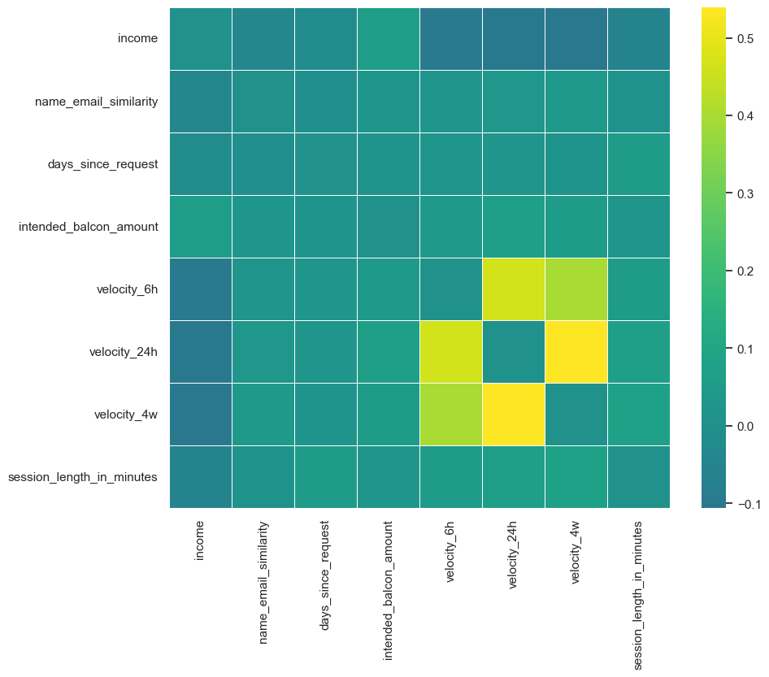

```
0
```

```python
get_corr_matrix(dataset = bf_train[list_var_continuous],
                metodo='pearson', size_figure=[10,8])
```

Observamos las variables que tienen mayor correlación, en este caso solo hay una que tenga más de 0.5 (inicialmente era 0.6 pero ninguna correlación supera 0.6), que es la correlación de la velocidad de 4 semanas con la velocidad de 24 horas.

```python
corr = bf_train[list_var_continuous].corr('pearson')
new_corr = corr.abs()
new_corr.loc[:,:] = np.tril(new_corr, k=-1) # below main lower triangle of an array
new_corr = new_corr.stack().to_frame('correlation').reset_index().sort_values(by='correlation', ascending=False)
new_corr[new_corr['correlation']>0.5]
```

|  | level_0 | level_1 | correlation |
| --- | --- | --- | --- |
| 53 | velocity_4w | velocity_24h | 0.539338 |

```python
list_var_continuous
```

```
['income',
 'name_email_similarity',
 'days_since_request',
 'intended_balcon_amount',
 'velocity_6h',
 'velocity_24h',
 'velocity_4w',
 'session_length_in_minutes']
```

## TRATAMIENTO DE LAS VARIABLES CATEGORICAS

Hacemos nuestra lista de variables categóricas:

```python
list_var_cat
```

```
['fraud_bool',
 'payment_type',
 'employment_status',
 'email_is_free',
 'housing_status',
 'phone_home_valid',
 'phone_mobile_valid',
 'has_other_cards',
 'foreign_request',
 'source',
 'device_os',
 'keep_alive_session',
 'fraud_bool']
```

```python
X_train = bf_train[list(set(list_var_continuous))]
X_test = bf_test[list(set(list_var_continuous))]
imputer = KNNImputer(n_neighbors=2, weights="uniform") #Nearest neighbors imputation.
model = imputer.fit(X_train)
pd_input_train = pd.DataFrame(model.transform(X_train),
                      columns=[i+'_input' for i in list(set(list_var_continuous))],index=bf_train.index)
pd_input_test = pd.DataFrame(model.transform(X_test),
                      columns=[i+'_input' for i in list(set(list_var_continuous))],index=bf_test.index)
bf_input_train = pd.concat([bf_train, pd_input_train],axis=1).drop(list(set(list_var_continuous)),axis=1)
bf_input_test = pd.concat([bf_test, pd_input_test],axis=1).drop(list(set(list_var_continuous)),axis=1)
```

```python
bf_input_train
```

|  | prev_address_months_count | current_address_months_count | customer_age | payment_type | zip_count_4w | bank_branch_count_8w | date_of_birth_distinct_emails_4w | employment_status | credit_risk_score | email_is_free | housing_status | phone_home_valid | phone_mobile_valid | bank_months_count | has_other_cards | proposed_credit_limit | foreign_request | source | device_os | keep_alive_session | device_distinct_emails_8w | device_fraud_count | month | fraud_bool | days_since_request_input | name_email_similarity_input | velocity_4w_input | intended_balcon_amount_input | session_length_in_minutes_input | … |
| --- | --- | --- | --- | --- | --- | --- | --- | --- | --- | --- | --- | --- | --- | --- | --- | --- | --- | --- | --- | --- | --- | --- | --- | --- | --- | --- | --- | --- | --- | --- |
| 127256 | 46 | 3 | 20 | AB | 226 | 7 | 9 | CA | 187 | 1 | BC | 0 | 1 | 1 | 0 | 1000 | 0 | INTERNET | linux | 1 | 1 | 0 | 3 | 0 | 0.003958 | 0.544796 | 3192.821301 | -1.169423 | 0.573210 | … |
| 870157 | -1 | 169 | 50 | AC | 1112 | 0 | 8 | CA | 145 | 1 | BB | 1 | 1 | -1 | 1 | 1500 | 0 | INTERNET | linux | 0 | 1 | 0 | 5 | 0 | 0.000829 | 0.598342 | 4248.819203 | -1.125127 | 4.689973 | … |
| 118763 | 10 | 17 | 20 | AB | 436 | 4 | 24 | CA | 257 | 1 | BE | 0 | 1 | 31 | 1 | 500 | 0 | INTERNET | linux | 1 | 1 | 0 | 3 | 0 | 0.025046 | 0.598155 | 5031.142072 | 50.296290 | 13.844604 | … |
| 762902 | -1 | 20 | 50 | AB | 1322 | 8 | 5 | CA | 189 | 1 | BC | 0 | 1 | 1 | 0 | 1500 | 0 | INTERNET | macintosh | 0 | 1 | 0 | 5 | 0 | 0.021438 | 0.144201 | 4181.773925 | -1.360682 | 3.221002 | … |
| 535812 | -1 | 39 | 20 | AB | 712 | 10 | 8 | CA | 125 | 1 | BC | 1 | 1 | 5 | 0 | 200 | 0 | INTERNET | linux | 1 | 1 | 0 | 6 | 0 | 0.004518 | 0.289050 | 3320.911634 | -0.269324 | 14.183499 | … |
| ... | ... | ... | ... | ... | ... | ... | ... | ... | ... | ... | ... | ... | ... | ... | ... | ... | ... | ... | ... | ... | ... | ... | ... | ... | ... | ... | ... | ... | ... | … |
| 506724 | -1 | 92 | 50 | AA | 2299 | 3 | 8 | CE | 159 | 1 | BC | 0 | 1 | 28 | 0 | 1500 | 0 | TELEAPP | windows | 0 | 0 | 0 | 1 | 0 | 2.734798 | 0.744796 | 5424.082604 | 24.429314 | 7.638432 | … |
| 647468 | 12 | 41 | 30 | AB | 1600 | 12 | 20 | CB | 208 | 1 | BB | 1 | 1 | 30 | 0 | 1500 | 0 | INTERNET | windows | 0 | 1 | 0 | 0 | 0 | 0.015097 | 0.564489 | 6734.674507 | -0.934527 | 4.856038 | … |
| 109257 | -1 | 82 | 30 | AA | 529 | 12 | 10 | CB | 157 | 1 | BC | 1 | 1 | 31 | 1 | 500 | 0 | INTERNET | windows | 1 | 1 | 0 | 3 | 0 | 0.020410 | 0.362402 | 4296.419902 | 23.136496 | 2.125413 | … |
| 213175 | 54 | 5 | 30 | AC | 609 | 0 | 12 | CB | 219 | 0 | BB | 0 | 1 | -1 | 0 | 1500 | 0 | INTERNET | linux | 0 | 1 | 0 | 3 | 0 | 0.002076 | 0.506098 | 5175.422415 | -1.355307 | 2.797111 | … |
| 767155 | -1 | 40 | 20 | AB | 1466 | 36 | 12 | CA | 79 | 1 | BB | 0 | 1 | 28 | 0 | 200 | 0 | INTERNET | linux | 1 | 1 | 0 | 5 | 0 | 0.005680 | 0.915523 | 4278.027740 | -0.826374 | 10.478985 | … |

800000 rows × 32 columns

Creamos nuestra matriz de confusión:

```python
confusion_matrix = pd.crosstab(bf_input_train["fraud_bool"], bf_input_train["customer_age"])
print(confusion_matrix)
cramers_v(confusion_matrix.values)
```

```
customer_age     10      20      30      40      50     60    70   80  90
fraud_bool
0             16738  195758  247137  188674  109930  26942  4939  998  61
1                59     963    2090    2286    2248    909   211   53   4
```

```
0.06659764776709583
```

En el primer ejemplo cruzas las tablas de la variable target 'fraud_bool' con la variable 'customer_age', y nos da un valor de 6.67%

En este ejemplo cruza la misma variable, por lo que el porcentaje es igual 1 o muy cercano:

```python
confusion_matrix = pd.crosstab(bf_input_train["fraud_bool"], bf_input_train["fraud_bool"])
cramers_v(confusion_matrix.values)
```

```
0.9999426978916621
```

```python
confusion_matrix = pd.crosstab(bf_input_train["fraud_bool"], bf_input_train["payment_type"])
cramers_v(confusion_matrix.values)
```

```
0.038444396613630756
```

La variable bf_input_train tiene una dimensión de 800 mil filas y 32 columnas, y la variable bf_input_test tiene una dimensión de 200 mil filas y 32 columnas.

```python
print(bf_input_train.shape, bf_input_test.shape)
```

```
(800000, 32) (200000, 32)
```

```python
corr = bf_train[list_var_continuous].corr('pearson')
new_corr = corr.abs()
new_corr.loc[:,:] = np.tril(new_corr, k=-1) # below main lower triangle of an array
new_corr = new_corr.stack().to_frame('correlation').reset_index().sort_values(by='correlation', ascending=False)
new_corr[new_corr['correlation']>0.5]
```

|  | level_0 | level_1 | correlation |
| --- | --- | --- | --- |
| 53 | velocity_4w | velocity_24h | 0.539338 |

# Guardado de la tabla

```python
os.getcwd()
```

```
'c:\\Users\\guzzm\\Desktop\\APRENDIZAJE AUTOMATICO\\PracticaEDA\\notebooks'
```

Guardamos nuestras variables train y test ('bf_train' & 'bf_test') en unos nuevos csvs para utilizarlos en el 3º notebook.

```python
bf_train.to_csv("../data/train_pd_data_preprocessing_missing_outlier.csv")
bf_test.to_csv("../data/test_pd_data_preprocessing_missing_outlier.csv")
```

La variable bf_train tiene una dimensión de 800 mil filas y 32 columnas, y la variable bf_test tiene una dimensión de 200 mil filas y 32 columnas.

```python
print(bf_train.shape,bf_test.shape)
```

```
(800000, 32) (200000, 32)
```

# CONCLUSIÓN

En este segundo notebook hemos trabajado nuestro dataframe llamado 'bf'. Lo hemos tratado, observando si había algún valor missing (aunque no fuera NA como vimos en el primer notebook) y cambiando el formato de alguna de sus variables para cumplir con los objetivos. Hemos trabajado sobre todo con nuestra variable target 'fraud_bool', en un principio observando con un gráfico de barras cuál era el porcentaje del número de fraudes, para más adelante poder compararlo con otras variables exógenas como puede ser la edad, la renta o el tipo de pago (algunas con mayor o menor correlación, aunque solo hemos cuantificado la correlación entre las variables continuas).

Hemos cogido las variables continuas (list_var_continuous) para observar los valores outlier y el porcentaje de los null de dichas variables; y hemos creado la variable list_var_cat con las variables categóricas del dataframe. Hemos creado una matriz de confusión a partir de las variables continuas mediante el KNNi (Nearest neighbors imputation) y de las variables 'bf_input_train' y 'bf_input_test'. Nuestra data train y test ha sido guardada en unos csvs nuevos para su utilización en el tercer notebook.

Todo esto nos ha servido para mejorar nuestros conocimientos acerca del tratado de comandos para visualizar gráficos. De manera bastante sencilla (dos bucles), hemos sido capaces de generar 31 gráficos (20 con variables numéricas Y 11 variables categóricas) para su posterior comentario e interpretación. Además, nos ha servido para tratar un poco la base de datos original, transformándola a lo que más nos conviene para trabajar con ella.